# Effect of the borrower's economic condition on borrower's APR interest rate.

## by Rodrigo Dalamangas

## Investigation Overview

> In this investigation I'm most interested in figuring out what features affect the borrower's APR interest rate.

## Dataset Overview

> There are 113937 loan registers from November 2005 to March 2014 with 81 features. After a preliminary data wrangling it turns to 113912 loan register and 18 features. Most variables are numeric, but the variables ListingCategory, EmploymentStatus, IsBorrowerHomeowner and IncomeRange are categorial variables with the latter being an ordered variable with a financial level.

## Distribution of Borrower's APR interest rate

> Borrower's APR seem to have a relevant frequency of distribution starting on 0.10 until 0.40 with a large spike around 0.35. In this case the small bin size proves very illuminating.

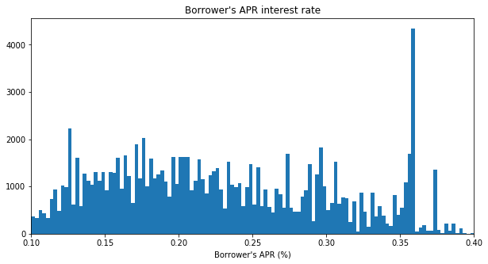

```python
bins = np.arange(0, loans['BorrowerAPR'].max()+0.0025,0.0025)
plt.figure(figsize=[10, 5])
plt.hist(data = loans, x = 'BorrowerAPR', bins=bins)
plt.xlim(0.1,0.4)
plt.xlabel('Borrower\'s APR (%)')
plt.title('Borrower\'s APR interest rate')
plt.show()
```

## Borrower's APR interest rate x borrower's income range or borrower's is home owner

> According to this plot, on average, people with their own homes and with high income have access to better values and rates of loans.

[figure not shown]

```python
categoric_vars = ['IsBorrowerHomeowner', 'IncomeRange']
default_color = sb.color_palette()[0]
# compute the logarithm of price to make multivariate plotting easier
def log_trans(x, inverse = False):
    """ quick function for computing log and power operations """
    if not inverse:
        return np.log10(x)
    else:
        return np.power(10, x)

loans['LogLoanAmount'] = loans['LoanOriginalAmount'].apply(log_trans)

fig, ax = plt.subplots(ncols = 2, nrows = 2 , figsize = [15,15])

for i in range(len(categoric_vars)):
    var = categoric_vars[i]
    sb.violinplot(data = loans, x = var, y = 'LogLoanAmount', ax = ax[i,0],
               color = default_color)
    ax[i,0].set_yticks(log_trans(np.array([2000, 5000, 10000,15000, 20000, 25000, 35000])))
    ax[i,0].set_yticklabels([2000, 5000, 10000,15000, 20000, 25000, 35000])
    ax[i,0].set_xticklabels(ax[i,0].get_xticklabels(), rotation=45, horizontalalignment='right')
    ax[i,0].set_xlabel('Borrower\'s income range')
    ax[i,0].set_ylabel('Loan Amount ($)')
    ax[i,0].set_title('Borrower\'s APR interest rate x borrower\'s income range')
    sb.violinplot(data = loans, x = var, y = 'BorrowerAPR', ax = ax[i,1],
               color = default_color)
    ax[i,1].set_xticklabels(ax[i,1].get_xticklabels(), rotation=45, horizontalalignment='right')
    ax[i,1].set_xlabel('Borrower\'s is home owner')
    ax[i,1].set_ylabel('Borrower\'s APR (%)')
    ax[i,1].set_title('Borrower\'s APR interest rate x borrower\'s is home owner')

plt.show()
```

## Borrower\'s APR across borrower\'s income range and borrower\'s is home owner

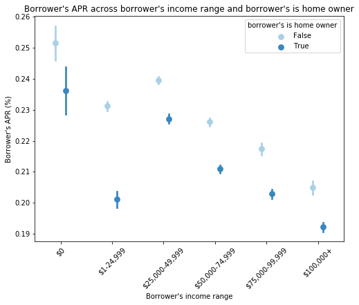

```python
fig = plt.figure(figsize = [8,6])
ax = sb.pointplot(data = loans, x = 'IncomeRange', y = 'BorrowerAPR', hue = 'IsBorrowerHomeowner',
           palette = 'Blues', linestyles = '', dodge = 0.2)
plt.title('Borrower\'s APR across borrower\'s income range and borrower\'s is home owner')
plt.ylabel('Borrower\'s APR (%)')
plt.xlabel('Borrower\'s income range')
plt.xticks(rotation=45)
ax.legend(title = 'borrower\'s is home owner')
plt.show();
```